# Fjellrype

Klikk her for å se starten på utregningen av indiatorverdien som ble gjort av Markus F Israelsen.

På denne siden gjør jeg de siste stegene i analysen og viser resultatene.

# Import

```r
dat <- read_excel("../output/indicator_values/fjellrype.xlsx")
head(dat)
```

```
## # A tibble: 6 x 12
##   `2010` `2011` `2012` `2013` `2014` `2015` `2016` `2017` `2018` `2019` `2020`
##    <dbl>  <dbl>  <dbl>  <dbl>  <dbl>  <dbl>  <dbl>  <dbl>  <dbl>  <dbl>  <dbl>
## 1      1  2.94   1.37    1.98   1.97   1.67  1.08    2.26   1.81  1.71   0.919
## 2      1  0.706  2.27    1.50   3.71   2.13  1.27    1.32   1.18  1.15   1.41
## 3      1  1.31   0.819   3.07   2.16   1.71  0.876   1.85   1.67  1.27   2.51
## 4      1  0.973  1.47    1.86   5.06   1.30  3.16    1.99   1.05  1.87   1.39
## 5      1  2.63   1.20    1.37   1.86   1.66  0.875   4.79   1.07  0.893  0.691
## 6      1  1.50   2.19    1.14   2.39   1.58  2.38    1.66   1.99  1.31   0.678
## # ... with 1 more variable: Region <chr>
```

Dette er bootstrappede indikatorverdier, skalerte mot indeksåret 2010.

La oss få dette over i langt format.

```r
setDT(dat)
dat <- melt(dat,
            id.vars = 'Region')
head(dat)
```

```
##    Region variable value
## 1:   nord     2010     1
## 2:   nord     2010     1
## 3:   nord     2010     1
## 4:   nord     2010     1
## 5:   nord     2010     1
## 6:   nord     2010     1
```

```r
names(dat) <- c("reg", "year", "value")
table(dat$reg, dat$year)
```

```
##
##         2010  2011  2012  2013  2014  2015  2016  2017  2018  2019  2020
##   midt 10000 10000 10000 10000 10000 10000 10000 10000 10000 10000 10000
##   nord 10000 10000 10000 10000 10000 10000 10000 10000 10000 10000 10000
##   sør  10000 10000 10000 10000 10000 10000 10000 10000 10000 10000 10000
##   vest 10000 10000 10000 10000 10000 10000 10000 10000 10000 10000 10000
##   øst  10000 10000 10000 10000 10000 10000 10000 10000 10000 10000 10000
```

10 000 verdier per kombinasjon.

Gir regionene nytt navn.

```r
unique(dat$reg)
```

```
## [1] "nord" "midt" "øst"  "vest" "sør"
```

```r
dat$reg <- plyr::revalue(dat$reg,
      c("nord"="N",
        "midt"="C",
        "øst" ="E",
        "vest"="W",
        "sør"="S"))
```

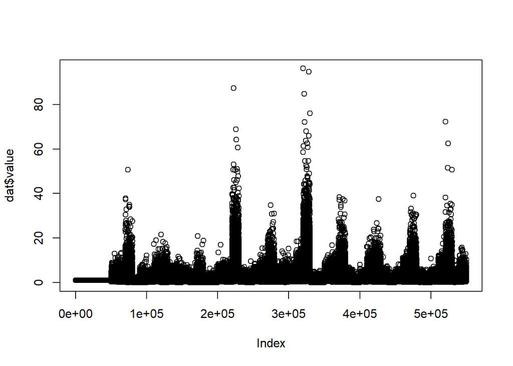

```r
plot(dat$value)
```

Det er mange høye verdier. En verdi på 2 tilsier 2x så mange ryper som i 2010.

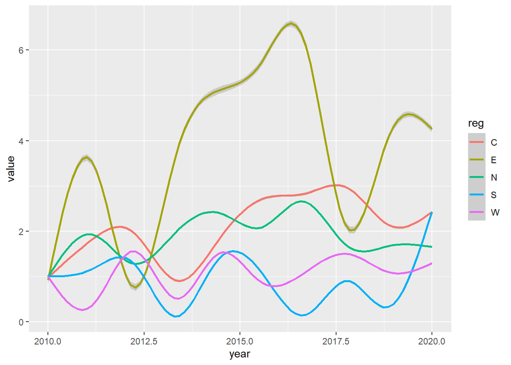

```r
dat$year <- as.numeric(as.character(dat$year))
ggplot(data=dat, aes(x = year, y = value, group= reg, colour = reg))+
  geom_smooth()
```

Det har vært en bedring i bestandedn i de siste årene. Østlandet har noen store svingninger.

Nå må vi skalere dataene etter en referansetilstand, som vi henter fra Naturindeksen. Der er det oppgitt hvor stor prosentanndel av referasnetilstanden som var realisert i 2010.

# Henter referansetilstand

Fyll inn ditt eget passord og brukernavn

```r
myUser <- "anders.kolstad@nina.no"
myPwd  <- "" # hemmelig passord
```

Importerer data fra NI-databasen

```r
ref <- NIcalc::importDatasetApi(
  username = myUser,
  password = myPwd,
  eco = "Fjell",
  indic = "Fjellrype",
  year = c(2010))
saveRDS(ref, "../data/fjellrypeNIexport.rds")
```

```r
ref <- readRDS("../data/fjellrypeNIexport.rds")
```

```r
ref2 <- ref$referenceValues$referenceValues
ref2 <- select(ref2, ICunitName, expectedValue)
```

Det er usikkerhet knyttet til referanseverdiene, men her behandler jeg dem som faste.

```r
comp <- ref$indicatorObservations$indicatorValues
comp <- select(comp, ICunitName, expectedValue)
ref2$comp <- comp$expectedValue[match(ref2$ICunitName, comp$ICunitName)]
head(ref2)
```

```
## # A tibble: 6 x 3
##   ICunitName expectedValue  comp
##   <chr>              <dbl> <dbl>
## 1 Hedmark             49.3  17.2
## 2 Oppland            114.   35.7
## 3 Buskerud            42.3  14.8
## 4 Telemark            38.6  19
## 5 Aust-Agder          19.7  12.7
## 6 Vest-Agder          17.7  13
```

Så må jeg summere bestandsestimate for hver region

```r
ref2$reg <- NA
ref2$reg[ref2$ICunitName == "Hedmark" |
          ref2$ICunitName == "Oppland"|
           ref2$ICunitName == "Buskerud"] <- "E"

ref2$reg[ref2$ICunitName == "Telemark" |
          ref2$ICunitName == "Aust-Agder"|
           ref2$ICunitName == "Vest-Agder"] <- "S"

ref2$reg[ref2$ICunitName == "Rogaland" |
          ref2$ICunitName == "Hordaland"|
           ref2$ICunitName == "Sogn og Fjordane"] <- "W"


ref2$reg[ref2$ICunitName == "Møre og Romsdal" |
          ref2$ICunitName == "Sør-Trøndelag"|
           ref2$ICunitName == "Nord-Trøndelag"] <- "C"

ref2$reg[ref2$ICunitName == "Nordland" |
          ref2$ICunitName == "Troms"|
           ref2$ICunitName == "Finnmark"] <- "N"
```

```r
ref3 <- aggregate(data=ref2,
                  expectedValue~reg,
                  FUN = sum)
temp <- aggregate(data=ref2,
                  comp~reg,
                  FUN = sum)
ref3$comp <- temp[,2]
ref3$realisert <- ref3$comp/ref3$expectedValue
```

## Skalerer TRIMverdiene mot referansetilstand

```r
dat$factor <- ref3$realisert[match(dat$reg, ref3$reg)]
dat$val <- dat$value*dat$factor
# trunkerer
dat$val[dat$val >1] <- 1
```

# Veiing

Regner ut nasjonale indikatorverider som et veid (etter total fjellareal) gjennomsnitt av vedien i regionene. Veiingen gjøres ved å samle større antall verdier for de regionene som har mest fjell i seg.

```r
wgt <- readRDS("../data/fjellareal.rds")
wgt$Fjellareal2 <- wgt$Fjellareal/max(wgt$Fjellareal)
wgt$reg <- c("N", "C", "E", "W", "S")
```

```r
myYears <- 2010:2020

datNorge <- data.frame(
  reg = rep("Norge", 110000),
  year = rep(2010:2020, each = 10000),
  val = NA
)

for(n in myYears){
    temp <- dat[dat$year == n,]

    temp2 <- c(
      sample(temp$val[temp$reg == "N"], wgt$Fjellareal2[wgt$reg == "N"]*10000, replace =T),
      sample(temp$val[temp$reg == "E"], wgt$Fjellareal2[wgt$reg == "E"]*10000, replace =T),
      sample(temp$val[temp$reg == "W"], wgt$Fjellareal2[wgt$reg == "W"]*10000, replace =T),
      sample(temp$val[temp$reg == "S"], wgt$Fjellareal2[wgt$reg == "S"]*10000, replace =T),
      sample(temp$val[temp$reg == "C"], wgt$Fjellareal2[wgt$reg == "C"]*10000, replace =T)
    )

    datNorge$val[datNorge$year == n] <- sample(temp2, 10000, replace = T)
}
```

```r
dat <- rbind(select(dat, reg, year, val), datNorge)
```

# Plotting

```r
eval(parse("indicator_plots2.R", encoding="UTF-8"))
```

```r
png("../output/indicatorPlots/skalert/fjellrype.png",
    units="in", width=12, height=7, res=300)

par(mfrow=c(1,1), mar=c(4.5,
                        5.5,
                        0,
                        2))

indicator_plot2(dataset = dat,
               yAxisTitle = "Fjellrypebestand skalert mot referanseverdi",
               lowYlimit = 0,
               upperYlimit = 1.2,
               yStep = .2,
               minyear = 2009,
               maxyear = 2021,
               colours = c("#FFB25B", "#2DCCD3", "#004F71", "#7A9A01", "#93328E", "dark grey"),
               legendPosition = "top",
               legendInset = 0,
               move = 0.05,
               horizontal = T,
               legendTextSize = 1.25)

dev.off()
```

Det blir så stor variasjon her at det er vanskelig å lese figuren:

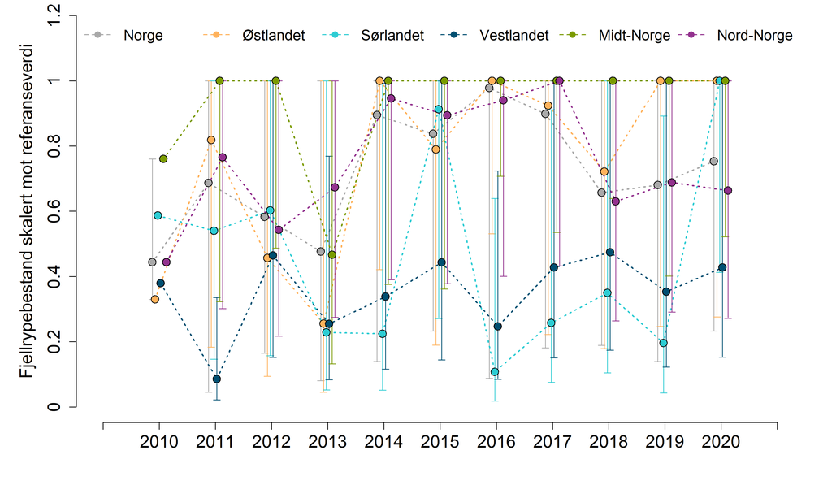

```r
finalTbl <- aggregate(data=dat,
          val~year+reg,
          FUN= function(x) round(
            quantile(x, c(.025, .5, .975)), 2))

finalTbl <- do.call(data.frame, finalTbl)
names(finalTbl) <- c("year", "reg", "low", "med", "upp")

DT::datatable(
  finalTbl,
  extensions = "FixedColumns",
  options = list(
    scrollX = TRUE,
    scrollY=T,
    pageLength = 10
  ))
```

|  | year | reg | low | med | upp |
| --- | --- | --- | --- | --- | --- |
| 1 | 2010 | C | 0.76 | 0.76 | 0.76 |
| 2 | 2011 | C | 0.32 | 1 | 1 |
| 3 | 2012 | C | 0.49 | 1 | 1 |
| 4 | 2013 | C | 0.13 | 0.47 | 1 |
| 5 | 2014 | C | 0.38 | 1 | 1 |
| 6 | 2015 | C | 0.36 | 1 | 1 |
| 7 | 2016 | C | 0.71 | 1 | 1 |
| 8 | 2017 | C | 0.54 | 1 | 1 |
| 9 | 2018 | C | 0.64 | 1 | 1 |
| 10 | 2019 | C | 0.4 | 1 | 1 |

[output cut: 56 more lines]

Her er en annen figur som ikke viser variasjonen.

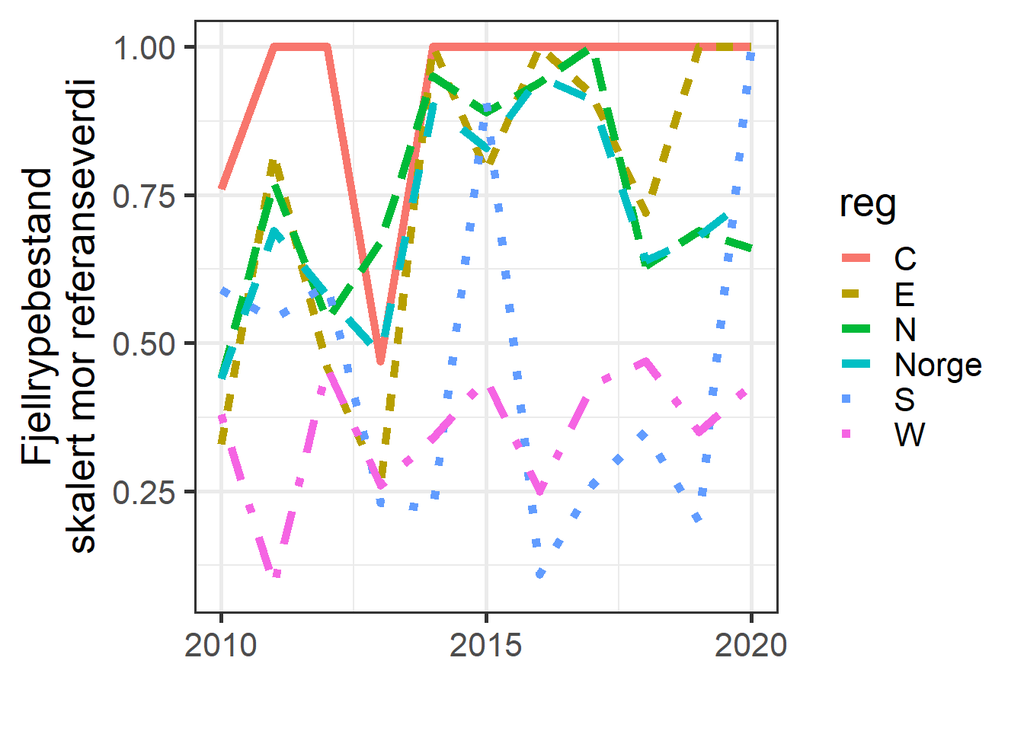

```r
ggplot(data=finalTbl, aes(x = year, y = med, group = reg, linetype=reg, colour=reg))+
  geom_line(size=2)+
  theme_bw(base_size = 20)+
  ylab("Fjellrypebestand\nskalert mor referanseverdi")+
  scale_x_continuous(breaks=c(2010, 2015, 2020))+
  xlab("")
```

Og en versjon til

```r
gg <- ggplot(data = finalTbl, aes(x = year, y = med))+
  geom_line(size=1.2, colour="grey30")+
  geom_errorbar(aes(ymax=upp, ymin=low), size = .8,
                colour="grey30",
                alpha=0.6,
                width=0.5)+
  theme_bw(base_size = 20)+
  theme(
    axis.text.x = element_text(angle = 90, vjust = 0.5, hjust=1)
  )+
  scale_x_continuous(breaks = c(2010, 2012, 2014, 2016, 2018, 2020))+
  ylab("Fjellrypebestand\nskalert mot referanseverdi")+
  xlab("")+
  facet_wrap(.~reg)
```

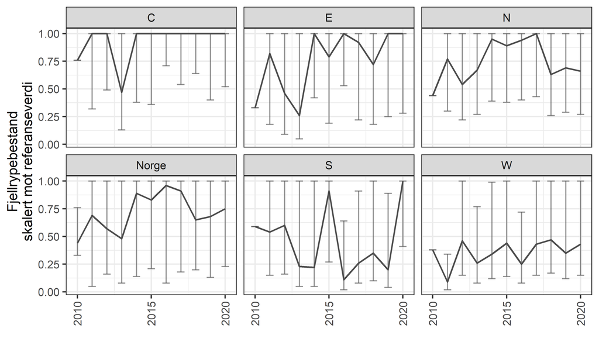

```r
png("../output/indicatorPlots/fjellrype_facet.png",
    units="in", width=12, height=7, res=300)

gg

dev.off()
```

Som alltid, errorbars er 95%CI.

# Eksporter csv

```r
write.csv(dat, "../output/indicator_values/fjellrype.csv", row.names = F)
```